# Instructions for the Assignments

Johan Larsson

For each assignment, as well as for the project, you need to hand in a `.pdf` report. This report should be a written response to the tasks given in the assignment. It should respond to all the questions in the assignment in a **clear** and **succinct** manner.

## Workflow: Two Approaches

There are two approaches you can take when you write your report. The first of these is to use R Markdown; the second is to write your report in a WYSIWYG (what you see is what you get) software such as Libre Office, Google Docs, or Microsoft Word.

### R Markdown

If you want to go down this road, start by downloading the submission template that we have provided for you by running the following code,

```r
download.file(
  "https://raw.githubusercontent.com/stat-lu/STAE04/master/stae04-template.Rmd",
  "stae04-template.Rmd", # replace this if you want to
  mode = "wb"
)
```

which will download and save the file to your working directory.

The template also serves as an introduction to R Markdown. To get started, simply open the document in R Studio and read through the code and text.

#### Pros

- You don’t need to bother with formatting details. R Markdown, pandoc, and LaTeX takes care of it all for you.
- It’s very convenient to modify figures or change image sizes. (Simply change `fig.width` and `fig.height` in the header).
- Your document becomes reproducible by someone else if you just give them the `.Rmd` file (and sometimes some other additional auxiliary files).
- Code that you include is automatically formatted and receives pretty syntax highlighting.

#### Cons

- You need to learn Markdown syntax and R Markdown code chunks, which will require an initial time investment. If you don’t expect to write these kinds of reports or presentations in the future or will be working with people who will not use R Markdown, this investment may not pay off.
- There are sometimes technical difficulties in getting R Markdown working, especially for Windows machines[^1].

### WYSIWYG

If you prefer to use a WYSIWYG editor, you will likely want to either use `ggplot2::ggsave()` or the built-in export utility in the plot pane of R Studio to save your plots to your hard drive and then input them manually into your document. Here is a simple example of how to do this:

```r
library(ggplot2)

ggplot(mpg, aes(cty, hwy)) +
  geom_point()

ggsave("filename.png", width = 3, height = 2.3)
```

#### Pros

- You probably already are familiar with Microsoft Word or Google Docs, so you can get going quickly.

#### Cons

- Modifying figures is a little bit of a hassle since you need to re-import the figure every time you modify the plot or make changes to its size.
- When you want (or need) to include code, you need to format it yourself by using a mono-spaced font (such as Courier or Consolas), and will not get syntax highlighting.

## Detailed Requirements

### Writing

Your report does not need to be verbose but it must be **clear** and **coherent**. Use full sentences and describe the steps you take and code you’ve included. Prefer a walk-through approach rather than a question: answer format. Someone who has not seen the assignment instructions should (reasonably well) be able to read your report.

### Figures

Any figures you include should have descriptive labels and captions. If you are using R Markdown, please use the `fig.cap` argument in the R Markdown chunk header to provide a caption. Also make use of `fig.width` and `fig.height` to control the size of the figures. A code chunk for a figure might look something like this:

````
```{r, fig.cap = "Engine displacement and number of cylinders for 38 popular models of cars from <https://fueleconomy.gov>.", fig.width = 4.2, fig.height = 3.7}
library(tidyverse)

mpg %>%
  ggplot(aes(cyl, displ)) +
  geom_point() +
  labs(x = "Number of Cylinders",
       y = "Engine Displacement")
```
````

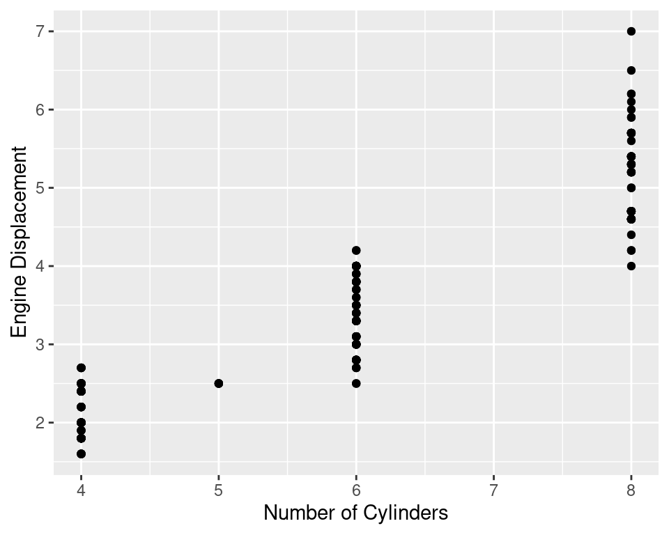

Engine displacement and number of cylinders for 38 popular models of cars from https://fueleconomy.gov.

If you use a WYSIWYG editor, you need to first import your images into the editor and then right-click on them and choose `Insert Caption` (or some similar command). **Don’t use `ggtitle()`, `labs(title = ...)`!**

See [The Anatomy of a Plot](https://stat-lu.github.io/STAE04/misc-the-anatomy-of-a-plot) for examples and more instruction on how to format your figures.

### Code

Only include code when you are **instructed** to do so. When you do include code, please avoid having it escape into the margin by using multiple lines to separate code. Good code style is not a requirement in this course but is nevertheless good practice. It might be a good idea to conform to a style guide such as [the tidyverse style guide](https://style.tidyverse.org/). R Studio can also format code for you if you select it and hit `Cmd/Ctrl + Alt + a`.

## Peer Review and Examination

For each assignment you will need to peer review **three other reports**. To complete these reviews, you need to fill out the **rubric** associated with the assignment and add a general comment on the submission. In addition, we also encourage you to provide **annotated feedback** using the integrated tools in Canvas. Please see [this page](https://community.canvaslms.com/t5/Student-Guide/How-do-I-submit-a-peer-review-to-an-assignment/ta-p/293) to read more about peer-reviewing in canvas.

Finally, please remember to provide **constructive** feedback.

### You have one week to complete your peer review!

If you have not completed your peer review within one week past the deadline, you will **fail the assignment**.

### Grading

The assignments and project will be graded by an instructor or teaching assistant as **pass** or **fail**. To pass the course, **you need to pass each assignment**. If you fail any assignment (or the project), you will get an additional chance to hand in these after the conclusion of the course.

## Hints

- Functions in the tidyverse are well-documented. Students who are successful at these assignments often make good use of the help files for the various functions. (In RStudio simply place the cursor on the function name and hit F1).
- To run code in R Studio inside a R Markdown document, highlight the code and hit `Ctrl/Cmd + Enter`. (There is no need to copy it directly into the terminal.)
- To create a code chunk in your R Markdown document, use the shortcut `Ctrl/Cmd + Alt + i`.
- If you want code in your R Markdown document to appear inside your final report, use `echo = TRUE` in the header of the code chunk.
- The size of figures can be controlled using the `fig.width` and `fig.height` options in the code header (if you use R Markdown) and the `width` and `height` arguments in `ggsave()` if you use a WYSIWYG editor. **Please don’t resize the images inside the editor**, which will risk making the annotation in the visualization hard to read.
[^1]: This is typically not a problem since you can export your document to a Word document instead of a PDF.